# The IBM attrition dataset

Business Analytics (23/24)

```r
library(tidymodels)
library(modeldata)
library(themis)
```

# 1 The `attrition` Dataset

These data are from the *IBM Watson Analytics Lab*. It is a fictional data set created by IBM data scientists. There are 1470 rows

```r
attrition <- tibble(attrition)
attrition <- janitor::clean_names(attrition)
str(attrition)
```

```
tibble [1,470 × 31] (S3: tbl_df/tbl/data.frame)
 $ age                       : int [1:1470] 41 49 37 33 27 32 59 30 38 36 ...
 $ attrition                 : Factor w/ 2 levels "No","Yes": 2 1 2 1 1 1 1 1 1 1 ...
 $ business_travel           : Factor w/ 3 levels "Non-Travel","Travel_Frequently",..: 3 2 3 2 3 2 3 3 2 3 ...
 $ daily_rate                : int [1:1470] 1102 279 1373 1392 591 1005 1324 1358 216 1299 ...
 $ department                : Factor w/ 3 levels "Human_Resources",..: 3 2 2 2 2 2 2 2 2 2 ...
 $ distance_from_home        : int [1:1470] 1 8 2 3 2 2 3 24 23 27 ...
 $ education                 : Ord.factor w/ 5 levels "Below_College"<..: 2 1 2 4 1 2 3 1 3 3 ...
 $ education_field           : Factor w/ 6 levels "Human_Resources",..: 2 2 5 2 4 2 4 2 2 4 ...
 $ environment_satisfaction  : Ord.factor w/ 4 levels "Low"<"Medium"<..: 2 3 4 4 1 4 3 4 4 3 ...
 $ gender                    : Factor w/ 2 levels "Female","Male": 1 2 2 1 2 2 1 2 2 2 ...
 $ hourly_rate               : int [1:1470] 94 61 92 56 40 79 81 67 44 94 ...
 $ job_involvement           : Ord.factor w/ 4 levels "Low"<"Medium"<..: 3 2 2 3 3 3 4 3 2 3 ...
 $ job_level                 : int [1:1470] 2 2 1 1 1 1 1 1 3 2 ...
 $ job_role                  : Factor w/ 9 levels "Healthcare_Representative",..: 8 7 3 7 3 3 3 3 5 1 ...
```

[output cut: 17 more lines]

Our job will be predicting the binary `attrition` target variable. As the positive case corresponds with the `Yes` level, we must modify the target variable so that it is the first level.

```r
attrition <- attrition |>
  mutate(attrition = factor(attrition, levels = c("Yes", "No")))
```

Examining the target variable, we observe it is unbalanced (there are more negative than positive cases).

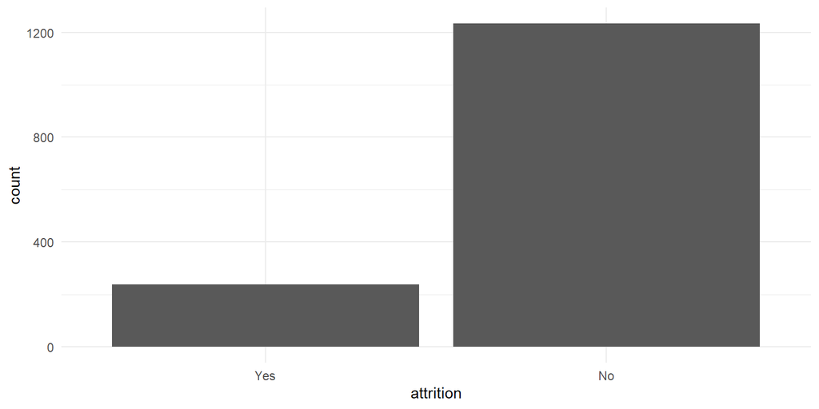

```r
ggplot(attrition, aes(attrition)) +
  geom_bar() +
  theme_minimal()
```

# 2 Predicting Personnel Attrition

Let’s define a predicting workflow for the attrition dataset, completing the steps described in this section.

## 2.1 Train and Test Split

```r
set.seed(123123)
attrition_split <- initial_split(attrition, prop = 0.8, strata = attrition)
at_train <- training(attrition_split)
at_test <- testing(attrition_split)
```

## 2.2 Data Preprocessing

Preparing an adequate preprocessing of the dataset in a recipe. Here are some hints to do the job:

- Transform factors into numeric variables. Take into account that there are ordered and unordered factors.
- Remove variables with low variance.
- Remove variables highly correlated with other features.

Also considering oversampling or undersampling to account for class imbalance.

```r
at_rec <- recipe(attrition ~ ., data = at_train) %>%
  step_dummy(all_nominal_predictors()) %>%
  step_zv(all_predictors()) %>%
  step_corr(all_numeric_predictors()) %>%
  step_smote(attrition) #to consider oversampling
at_rec
```

```
── Recipe ──────────────────────────────────────────────────────────────────────
```

```
── Inputs
```

```
Number of variables by role
```

```
outcome:    1
predictor: 30
```

```
── Operations
```

```
• Dummy variables from: all_nominal_predictors()
```

```
• Zero variance filter on: all_predictors()
```

```
• Correlation filter on: all_numeric_predictors()
```

```
• SMOTE based on: attrition
```

We can see the preprocessed dataset doing:

```r
at_rec %>%
  prep() %>%
  bake(new_data = NULL)
```

```
# A tibble: 1,972 × 56
     age daily_rate distance_from_home hourly_rate monthly_income monthly_rate
   <dbl>      <dbl>              <dbl>       <dbl>          <dbl>        <dbl>
 1    49        279                  8          61           5130        24907
 2    33       1392                  3          56           2909        23159
 3    27        591                  2          40           3468        16632
 4    32       1005                  2          79           3068        11864
 5    59       1324                  3          81           2670         9964
 6    30       1358                 24          67           2693        13335
 7    38        216                 23          44           9526         8787
 8    36       1299                 27          94           5237        16577
 9    35        809                 16          84           2426        16479
10    29        153                 15          49           4193        12682
# ℹ 1,962 more rows
# ℹ 50 more variables: num_companies_worked <dbl>, percent_salary_hike <dbl>,
#   stock_option_level <dbl>, total_working_years <dbl>,
#   training_times_last_year <dbl>, years_at_company <dbl>,
#   years_in_current_role <dbl>, years_since_last_promotion <dbl>,
#   years_with_curr_manager <dbl>, business_travel_Travel_Frequently <dbl>,
#   business_travel_Travel_Rarely <dbl>, department_Sales <dbl>, …
```

## 2.3 Models

Choosing two models that can be adequate for this dataset, and define workflows to integrate them with the recipe or recipes.

```r
# Logistic Regression Model
logistic_model <- logistic_reg() %>%
  set_engine("glm")

logistic_workflow <- workflow() %>%
  add_model(logistic_model) %>%
  add_recipe(at_rec)

# Random Forest Model
forest_model <- rand_forest(trees = 50) %>%
  set_engine("ranger") %>%
  set_mode("classification")

forest_workflow <- workflow() %>%
  add_model(forest_model) %>%
  add_recipe(at_rec)
```

## 2.4 Cross Validation

Defining a cross validation scheme with five folds, and evaluate each of the models with the following metrics:

- Accuracy.
- Sensitivity.
- Specificity.

```r
set.seed(123123)
attrition_folds <- vfold_cv(at_train, v = 5, strata = attrition)
```

```r
metrics <- metric_set(accuracy, sens, spec)
```

```r
logistic_res <- fit_resamples(
  logistic_workflow,
  resamples = attrition_folds,
  metrics = metrics
)

forest_res <- fit_resamples(
  forest_workflow,
  resamples = attrition_folds,
  metrics = metrics
)
logistic_res %>%
  collect_metrics()
```

```
# A tibble: 3 × 6
  .metric  .estimator  mean     n std_err .config
  <chr>    <chr>      <dbl> <int>   <dbl> <chr>
1 accuracy binary     0.794     5  0.0181 Preprocessor1_Model1
2 sens     binary     0.740     5  0.0244 Preprocessor1_Model1
3 spec     binary     0.804     5  0.0195 Preprocessor1_Model1
```

```r
forest_res %>%
  collect_metrics()
```

```
# A tibble: 3 × 6
  .metric  .estimator  mean     n std_err .config
  <chr>    <chr>      <dbl> <int>   <dbl> <chr>
1 accuracy binary     0.858     5 0.00405 Preprocessor1_Model1
2 sens     binary     0.212     5 0.0220  Preprocessor1_Model1
3 spec     binary     0.982     5 0.00413 Preprocessor1_Model1
```

# 3 Assessing Best Model

Selecting the best model from the ones tested, train it with the whole train set and obtain the prediction metrics with the test set.

-> We have an imbalanced dataset, with more negative than positive cases. When comparing the two models, the random forest model has better accuracy and specificity, making it highly effective at identifying negative cases. However, the logistic regression model (model 1) has significantly better sensitivity, which is crucial for identifying positive cases. Therefore, I chose the logistic regression model to better address the class imbalance and improve the detection of positive cases.

```r
best_model <- logistic_workflow %>% fit(at_train)

final_fit <- best_model %>%
  predict(at_test) %>%
  bind_cols(at_test) %>%
  conf_mat(truth= attrition, estimate = .pred_class)


metrics <- metric_set(sens, yardstick::spec, accuracy)
best_model %>%
  predict(at_test) %>%
  bind_cols(at_test) %>%
  metrics(truth = attrition, estimate = .pred_class)
```

```
# A tibble: 3 × 3
  .metric  .estimator .estimate
  <chr>    <chr>          <dbl>
1 sens     binary         0.688
2 spec     binary         0.806
3 accuracy binary         0.786
```

```r
best_model %>%
  predict(at_test, type = "prob")
```

```
# A tibble: 295 × 2
   .pred_Yes .pred_No
       <dbl>    <dbl>
 1   0.0107     0.989
 2   0.412      0.588
 3   0.315      0.685
 4   0.00725    0.993
 5   0.232      0.768
 6   0.802      0.198
 7   0.107      0.893
 8   0.541      0.459
 9   0.0122     0.988
10   0.464      0.536
# ℹ 285 more rows
```